# Assignment 6

#### Note: Discussed with Janice Luong. I also used Google a lot to look up the different zipcodes and districts in San Francisco because I am not very familiar with the area since I did not grow up there.

In this assignment, you'll analyze a collection of data sets from the [San Francisco Open Data Portal](http://data.sfgov.org/) and [Zillow](https://www.zillow.com/). The data sets have been stored in the SQLite database `sf_data.sqlite`, which you can [download here](http://anson.ucdavis.edu/~nulle/sf_data.sqlite). The database contains the following tables:

| Table | Description |
| --- | --- |
| `crime` | Crime reports dating back to 2010. |
| `mobile_food_locations` | List of all locations where mobile food vendors sell. |
| `mobile_food_permits` | List of all mobile food vendor permits. More details [here](https://data.sfgov.org/api/views/rqzj-sfat/files/8g2f5RV4PEk0_b24iJEtgEet9gnh_eA27GlqoOjjK4k?download=true&filename=DPW_DataDictionary_Mobil… |
| `mobile_food_schedule` | Schedules for mobile food vendors. |
| `noise` | Noise complaints dating back to August 2015. |
| `parking` | List of all parking lots. |
| `parks` | List of all parks. |
| `schools` | List of all schools. |
| `zillow` | Zillow rent and housing statistics dating back to 1996. More details [here](https://www.zillow.com/research/data/). |

The `mobile_food_` tables are explicitly connected through the `locationid` and `permit` columns. The other tables are not connected, but you may be able to connect them using dates, latitude/longitude, or postal codes.

Shapefiles for US postal codes are available [here](https://www.census.gov/geo/maps-data/data/cbf/cbf_zcta.html). These may be useful for converting latitude/longitude to postal codes.

Shapefiles for San Francisco Neighborhoods are available [here](https://data.sfgov.org/Geographic-Locations-and-Boundaries/SF-Find-Neighborhoods/pty2-tcw4).

**Exercise 1.1.** Which mobile food vendor(s) sells at the most locations?

```python
import sqlite3 as sql
import pandas as pd
import matplotlib.pyplot as plt
import seaborn as sns
import geopandas as gpd

from mpl_toolkits.basemap import Basemap
```

```python
db = sql.connect("sf_data.sqlite")
```

```python
vendor_loc = pd.read_sql("SELECT P.Applicant as 'Vendor', Count(S.locationid) as 'Number of Locations' "
            "FROM mobile_food_permits AS P INNER JOIN mobile_food_schedule AS S on P.permit = S.permit "
            "WHERE P.Status = 'APPROVED' GROUP BY P.Applicant ORDER BY COUNT(S.locationid) DESC LIMIT 10", db)
vendor_loc
```

|  | Vendor | Number of Locations |
| --- | --- | --- |
| 0 | Park's Catering | 134 |
| 1 | D & T Catering | 85 |
| 2 | F & C Catering | 79 |
| 3 | Munch A Bunch | 52 |
| 4 | BH & MT LLC | 40 |
| 5 | Linda's Catering | 35 |
| 6 | San Francisco Carts & Concessions, Inc. DBA St... | 35 |
| 7 | Golden Catering | 31 |
| 8 | Eva's Catering | 22 |
| 9 | Subs on Hubs | 19 |

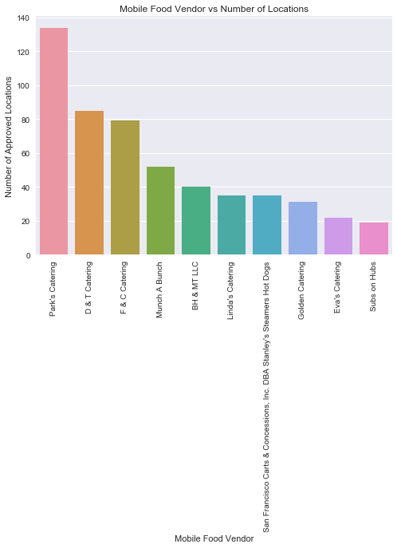

```python
vendor_bar = sns.barplot(x = "Vendor", y = "Number of Locations", data = vendor_loc)
#turns the fruit names on the x-axis so that they are readable
for item in vendor_bar.get_xticklabels():
    item.set_rotation(90)
#renaming the plot and changing the y and x labels for the axes
sns.plt.title('Mobile Food Vendor vs Number of Locations')
vendor_bar.set(ylabel = 'Number of Approved Locations', xlabel = 'Mobile Food Vendor')
sns.plt.show()
```

- Park's Catering sells at 134 locations, which makes them the vendor that sells at the most locations by a significant amount. They are followed by D&T Catering at 85 locations, F&C Catering at 79 locations, Munch A Bunch at 52 locations, and BH&MT LLC at 40 locations.

**Exercise 1.2.** Ask and use the database to analyze 5 questions about San Francisco. For each question, write at least 150 words and support your answer with plots. Make a map for at least 2 of the 5 questions.

You should try to come up with some questions on your own, but these are examples of reasonable questions:

- Which parts of the city are the most and least expensive?
- Which parts of the city are the most dangerous (and at what times)?
- Are noise complaints and mobile food vendors related?
- What are the best times and places to find food trucks?
- Is there a relationship between housing prices and any of the other tables?

Please make sure to clearly state each of your questions in your submission.

**Question 1: Which parts of the city are the most and least expensive?**

```python
#least_expensive
pd.read_sql("SELECT AVG(MedianSoldPricePerSqft_AllHomes) AS 'Median Price/sqft', RegionName AS 'Zipcode' "
            "FROM zillow GROUP BY RegionName ORDER BY AVG(MedianSoldPricePerSqft_AllHomes) ASC LIMIT 3 ", db)
```

|  | Median Price/sqft | Zipcode |
| --- | --- | --- |
| 0 | 297.008046 | 94124 |
| 1 | 347.027455 | 94134 |
| 2 | 375.629802 | 94080 |

```python
#most_expensive
most_expensive = pd.read_sql("SELECT AVG(MedianSoldPricePerSqft_AllHomes) AS 'Median Price/sqft', RegionName AS 'Zipcode' "
                             "FROM zillow GROUP BY RegionName ORDER BY AVG(MedianSoldPricePerSqft_AllHomes) DESC LIMIT 3 ", db)
most_expensive
```

|  | Median Price/sqft | Zipcode |
| --- | --- | --- |
| 0 | 1336.128581 | 94104 |
| 1 | 798.257824 | 94105 |
| 2 | 696.166788 | 94123 |

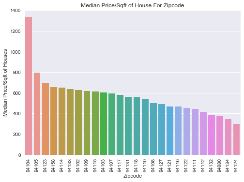

```python
all_prices = pd.read_sql("SELECT AVG(MedianSoldPricePerSqft_AllHomes) AS 'Median Price/sqft', RegionName AS 'Zipcode' "
                             "FROM zillow GROUP BY RegionName ORDER BY AVG(MedianSoldPricePerSqft_AllHomes) DESC", db)

all_prices_bar = sns.barplot(x = "Zipcode", y = "Median Price/sqft", order = all_prices['Zipcode'], data = all_prices)
#turns the fruit names on the x-axis so that they are readable
for item in all_prices_bar.get_xticklabels():
    item.set_rotation(90)
#renaming the plot and changing the y and x labels for the axes
sns.plt.title('Median Price/Sqft of House For Zipcode')
all_prices_bar.set(ylabel = 'Median Price/Sqft of Houses', xlabel = 'Zipcode')
sns.plt.show()
```

It is obvious that houses within the 94104 zipcode have the highest median price per square foot at around 1,336 dollars per square foot, which make homes in this zipcode the most expensive homes in San Francisco. The 94104 zipcode is a small area between the Financial District and Chinatown. It makes sense that this location would be such an expensive place to live because of the easy access to popular San Francisco locations. The second most expensive location to buy a home is in the 94105 zipcode, where the average median price per square foot is 798 dollars. This location is right below the Financial District but also hugs the coastline by the Oakland Bay Bridge, so between the easy access to popular San Francisco locations, some of the houses in this zipcode have a view of the San Francisco Bay, which is also worth a lot in terms of property value. The third most expensive location to live in San Francisco is within the area code 94123, which comes in at 696 dollars per square foot. This zipcode is in the Marina District, which again has access to popular locations, such as the Fisherman's Wharf, and it also has views of the water from specific locations.

The least expensive place to live in San Francisco are neighborhoods within the 94124 zipcode, at around 297 dollars per square foot. This zipcode includes locations like Hunters Point, which is a dangerous neighborhood. The next most inexpensive places to live is 94134, 347 dollars per square foot, which is also surrounded by areas that are not very safe, such as Hunters Point and the Outer Mission District. Lastly, the third least expensive zipcode to live within is 94080, around 376 dollars per square foot, which is South San Francisco. It may be cheaper to live there because you are outside of San Francisco proper.

Overall, locations that are close to popular locations around San Francisco, such as the wharf or the financial district, seem to have higher median prices per square foot on average. And locations that are father away from the popular locations and are surrounded by more dangerous neighborhoods, tend to have lower median prices per square foot.

**Question 2: Are noise complaints and mobile food vendors related?**

```python
#Automatically plot the maps
%matplotlib inline
```

```python
#create two different df for noise and vendor location to grab the lat and lon for both
noise_location = pd.read_sql("SELECT Lat, Lon FROM noise", db)
noise_location['type'] = 'Noise' #add row of 'Noise'
vendor_location = pd.read_sql("SELECT latitude AS 'Lat', longitude AS 'Lon' FROM mobile_food_locations", db)
vendor_location['type'] = 'Vendor' #add row of 'Vendor'

#combining all info into a single data frame for easy access while making the map below
pds = [noise_location, vendor_location]

noise_vendor_df = pd.concat(pds)
```

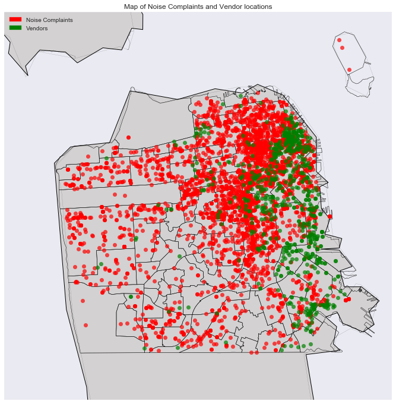

```python
import matplotlib.patches as patches

# Make plots larger.
plt.rcParams['figure.figsize'] = (12, 12)

#creating the boundaries for my map (upper right corner and lower left corner)
noise_food_map = Basemap(llcrnrlon=-122.54, llcrnrlat=37.69, urcrnrlon=-122.35, urcrnrlat=37.84, resolution="h",
    projection="merc")

#making specifications to the map
noise_food_map.drawcoastlines()
noise_food_map.drawcounties()
noise_food_map.fillcontinents(color='#d3d1d1',lake_color='#43d8c4')

#reading in the shapefile of SF Neighborhoods
noise_food_map.readshapefile("geo_export_4ecb8def-47e9-40dc-8253-22009a1fcf46", "sf_neighborhoods")

#plotting the lat and long for noise complaints and food vendors
for longitude, latitude, types in zip(noise_vendor_df.Lon, noise_vendor_df.Lat, noise_vendor_df.type):
    x, y = noise_food_map(longitude, latitude)
    # red if it is a noise complaint and green if it is a food vendor
    if types == 'Noise':
        color = "r"
    else:
        color = "g"
    noise_food_map.plot(x, y, color + "o", alpha = 0.7)


#creating the labels, the legend, and the title for the map
Noise_label = patches.Patch(color='r', label='Noise Complaints')
Vendor_label = patches.Patch(color='g', label='Vendors')
sns.plt.title('Map of Noise Complaints and Vendor locations')
plt.legend(handles=[Noise_label,Vendor_label], loc = 'upper left')
```

The red dots on the map respond to noise complaints across San Francisco. The green dots represent the locations of mobile food vendors. It is easy to see that there are both more noise complaints and more mobile food vendors on the eastern side of San Francisco. Looking at the map, it would seem safe to assume that mobile food vendors and noise complaints were correlated, especially in the Northeast part of San Francisco. This correlation may be because mobile food vendors are specifically looking for crowded and 'tourist-y' places to set up shop. It would make sense that places that get noise complaints are generally more crowded, which attracts mobile food vendors. However, there may be some confounding variables that make it seem as if food vendors and noise complaints were correlated. For example, the cluster of mobile food vendors falls near the financial district which would be ideal places for mobile food vendors to sell their food because the people who work within that district need to eat.

As for the places that have more spaced out noise complaints and food vendors, I would assume they are less attractive for tourists and more residential. Also, there will be noise complaints anywhere because there are some people who are serial complainers and will complain about anything.

**Question 3: What are the most common crimes? And what days of the week do those crime occur the most often?**

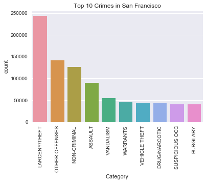

```python
crime_report = pd.read_sql("SELECT Category, PdDistrict, DayOfWeek FROM crime", db)

crime_cat = sns.countplot(x = "Category", data = crime_report, order=crime_report.Category.value_counts().iloc[:10].index)
for item in crime_cat.get_xticklabels():
    item.set_rotation(90)
sns.plt.title('Top 10 Crimes in San Francisco')
plt.show()
```

The crime that happens the most often, by quite a large margin, is larceny/theft. Other offenses and non-criminal crimes take ranks two and three. Assualt and vandalism round out the top five crimes reported in San Francisco. It makes sense that theft is the most common category of crimes, with around 240,000 cases, because so many tourists flock to San Francisco. Generally, tourists are less aware of what parts of the city are not as safe and are less likely to be wary of possible criminal acts, such as pick pockets or of people breaking into cars to steal things. Moving past other offenses, because it does not tell us much, the third most common crime is non-criminal. These types of crime can include thngs like intoxicated person or trespass warnings. It is surprising to me that there were so many non-criminal crimes but, in the scheme of things, the sum of all the criminal crimes far outweighs the non-criminal ones. Assualt and Vandalism are the final two crimes in the top five. These do not surprise me either because both of these crimes can happen on a semi-regular basis within the 'bad' neighborhoods throughout San Francisco.

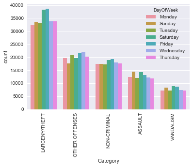

```python
crime_cat = sns.countplot(x = "Category", hue = "DayOfWeek", data = crime_report, order=crime_report.Category.value_counts().iloc[:5].index)
for item in crime_cat.get_xticklabels():
    item.set_rotation(90)
plt.show()
```

Of those top five most common crimes, a majority of them happen on weekends. Larceny/theft, non-criminal crimes, and vandalism all occur most often on Fridays and Saturdays. Additionally, assualt happens most often on Sundays, followed by Fridays and Saturdays. This makes sense because there are more tourists in the city on the weekend, people are drinking and not aware of their surroundings, and people are out later because they do not generally have work the next day. "Other offenses" occur most often on Wednesdays followed by Fridays and Tuesdays. This was surprising to me because I generally think of weekends as the time to be more on watch for crimes occuring, but because we don't know what is included in this 'other' category, it makes it hard to analyze.

**Question 4: Are there more parks near schools? Which type of school, public or private is closer to more parks?**

```python
#get two data frames from the schools and parks table to get lat and lon from both
education_table = pd.read_sql("SELECT Lat, Lon, Entity FROM schools", db)
parks_table = pd.read_sql("SELECT Lat, Lon FROM parks WHERE Type = 'Neighborhood Park or Playground'", db)

#combine the two tables into one to more easily map the lat and lon for both
dfs = [education_table, parks_table]
education_parks_df = pd.concat(dfs)
```

Note: I decided to only look at Neighborhood Parks/Playgrounds because they are defined to be "playgrounds and playing fields, courts and structures; internal trails, picnic/seating area, or dog parks." I did not want to be looking at state parks or mini parks because I did not think they were relevant to the question I was trying to answer.

Definition from: http://www.bakerprojects.com/dprmasterplan/pdf/classifications.pdf

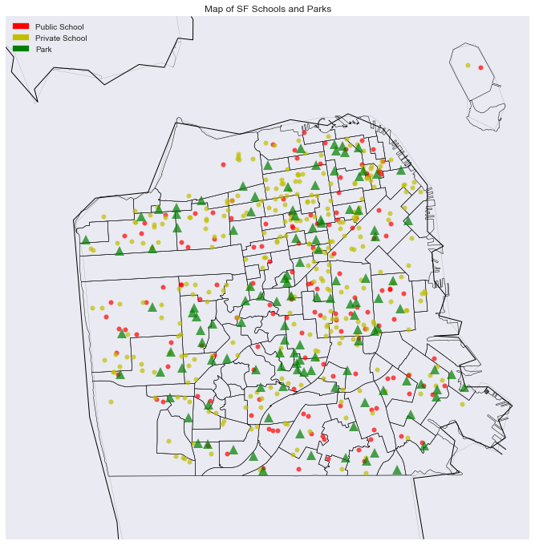

```python
# Make plots larger.
plt.rcParams['figure.figsize'] = (12, 12)

edu_park_map = Basemap(llcrnrlon=-122.54, llcrnrlat=37.69, urcrnrlon=-122.35, urcrnrlat=37.84, resolution="h",
    projection="merc")

edu_park_map.drawcoastlines()
edu_park_map.drawcounties()

edu_park_map.readshapefile("geo_export_4ecb8def-47e9-40dc-8253-22009a1fcf46", "sf_neighborhoods")

for longitude, latitude, entity in zip(education_parks_df.Lon, education_parks_df.Lat, education_parks_df.Entity):
    x, y = noise_food_map(longitude, latitude)
    # red if it is a public, blue if it is a priate school
    if entity == 'SFUSD' or entity == 'SFCCD':
        color = "r"
        marker = 'o'
        marker_size = 6
    elif entity == 'Private':
        color = 'y'
        marker = 'o'
        marker_size = 6
    else:
        color = "g"
        marker = '^'
        marker_size = 12
    edu_park_map.plot(x, y, color + marker, markersize = marker_size, alpha = 0.7)



Public_label = patches.Patch(color='r', label='Public School')
Private_label = patches.Patch(color='y', label='Private School')
Park_label = patches.Patch(color='g', label='Park')
sns.plt.title('Map of SF Schools and Parks')
plt.legend(handles=[Public_label, Private_label, Park_label], loc = 'upper left')
```

The map above shows parks, specifically neighborhood parks/playgrounds, in green triangles and school in circles. From the map, it can be seen that generally, there are schools clustered around parks. Obviously, if you find a park, you are not promised that you are going to find a school, or vice versa, but it seems to be a pretty good formula to follow. Again, there are also confounding variables that could be at play. For exmaple, it would also make sense to assume that suburban areas would have more kids within them. Kids need a place to learn and they need a place to play, so because of that, there would be more schools and parks in general.

The circles are distinguished by color, where red indicates a public schools and the yellow circle indicates a private schools. It surprised me how many private schools there were within San Francisco. However, it does make sense because to be able to live in most parts of San Francisco, you have to have a lot of money, and if you have a lot of money, you can afford to send your child to private school. Putting that thought aside, while looking at the map, I believe that private schools marginally beat out public schools for being closer to parks. When looking at the map, if you look at a yellow circle, I believe that you will see a green triangle slightly more often than you will if you are looking at a red circle.

**Question 5: What time and day of the week are you most likely to find a food vendor in San Francisco?**

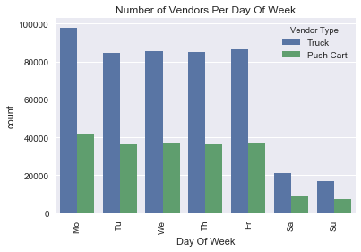

```python
food_table = pd.read_sql("SELECT l.locationid as 'LocationID', l.DayOfWeek as 'Day Of Week', l.StartHour as 'StartHour', l.EndHour as 'End Hour', "
                         "r.FacilityType as 'Vendor Type' FROM mobile_food_schedule l LEFT JOIN mobile_food_permits r", db)

food_table_bar = sns.countplot(x = "Day Of Week", hue = 'Vendor Type', data = food_table)
for item in food_table_bar.get_xticklabels():
    item.set_rotation(90)
sns.plt.title('Number of Vendors Per Day Of Week')
plt.show()
```

This table shows that the most number of vendors sell their product on Mondays. There are still a lot of choices for vendors throughout the other weekdays. But on the weekends, there are significantly less food trucks available to visit. This was surpising to me because I would have thought the opposite pattern would occur. The lack of vendors on the weekends may be due to an increase in permit price to sell their products on weekends or from lack of parking throughout the city for their trucks. However, it does make sense for vendors to be available throughout the week because that means that vendors are available to sell to people during their lunch break or on their communte if they are walking to and from work or school.

I did find it surprising that there were as many push carts throughout the city as there are. I figured that the number of food trucks would disproportionately outweigh the number of push carts. However, it does make sense because push carts are significantly less expensive to run than a food truck and are easier to manuever within the streets of San Francisco.

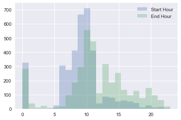

```python
plt.hist(food_table['StartHour'], bins = 24, alpha=.3, label='Start Hour')
plt.hist(food_table['EndHour'], bins = 24, alpha=0.3, label='End Hour')
plt.legend(loc='upper right')
plt.show()
```

From this graph, we can see that a large majority of vendors start their days in the morning, as early as 6, but specifically between 9 and 10 am. This makes a lot of sense because a lot of food vendors try and catch people while they are on their way to work or during their break for lunch. Surprisingly there are a large number of vendors who start at midnight, but because there are not many vendors openning after 8 pm, I believe this may be the default answer in case the vendor did not fill in this information.

We see the same pattern with midnight having an unusually high spike in ending hours, which makes me believe again that midnight is a default answer if the vendor did not answer this question. Otherwise, we can also see there is less consistency with the time that food vendors end their day, the only time that there is almost no vendors ending their day is between 4 and 5 in the morning. A large chunk of vendors end their day between 10 and 11 am, which means they probably specialize in breakfast products and close after the breakfast rush is over. The second chunk of vendors end their day between 1 pm and 3 pm, which would be after the lunch rush is over. Additionally, there are some vendors that end their day at a ridiculously late/early hours such as 11pm or 1 am, which may be because they are trying to catch people as they are leaving bars or shows late at night.